# ggplot2: An introduction

## Grouping and dodging

If you want to separate out the points so that they go under their boxplots again instead of jittering them, we can use a `position_dodge` in combination with `group`.

`position_dodge` adjusts the horizontal position of the data by using a grouping variable. In this case, we will set our grouping variable to also be sex, and add our `position_dodge` statement to the geom with a width of 0.75.

*Note: position_dodge - like jitter and alpha - is not an aesthetic and goes outside of the aes parenthesis but within the geom parenthesis.*

*In the weeds: You will notice that a position_dodge with a width of 0.75 aligns suspiciously perfectly with our boxplots. This is because boxplots are actually already using position_dodge by default when you add another variable like color!*

```r
ggplot(data = tidy_data,
       mapping = aes(x = species,
                     y = body_mass_g,
                     color = sex)) +
  geom_boxplot(outliers = FALSE) +
  geom_point(aes(group = sex),
              position = position_dodge(width = 0.75),
              alpha = 0.5)
```

We have lost our jitter, but we can add it back!

To add it back while retaining the grouping, we can simultaneously dodge and jitter by using `position_jitterdodge` and changing `width` to `dodge.width`

```r
ggplot(data = tidy_data,
       mapping = aes(x = species,
                     y = body_mass_g,
                     color = sex)) +
  geom_boxplot(outliers = FALSE) +
  geom_point(aes(group = sex),
             position = position_jitterdodge(dodge.width = 0.75,
                                              jitter.width = 0.25),
             alpha = 0.5)
```

This plot is looking pretty great!

## Labels and titles

The `labs` function is used to specify axis labels, titles, subtitles, etc.

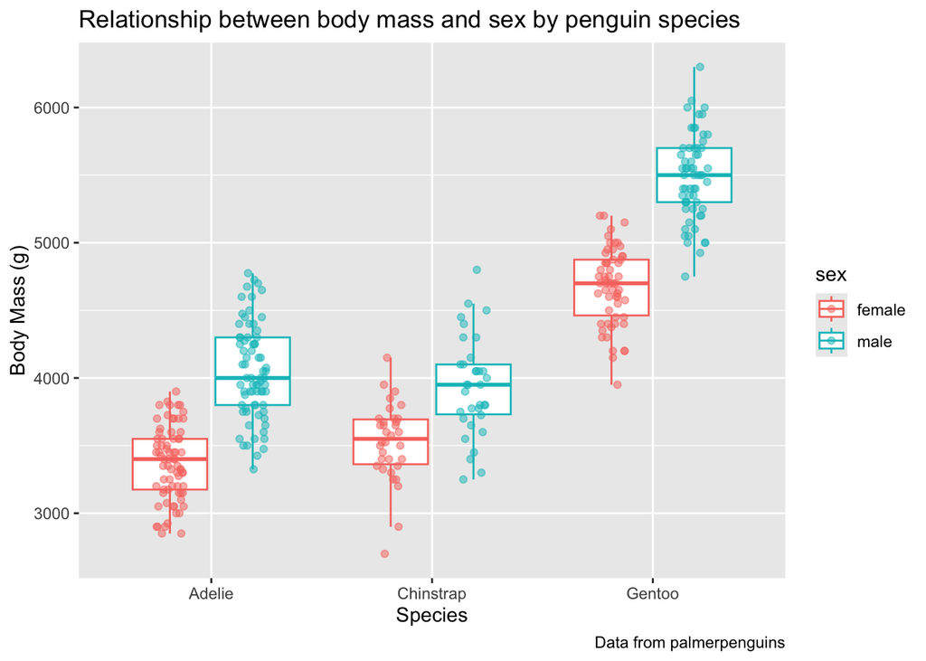

```r
ggplot(data = tidy_data,
       mapping = aes(x = species,
                     y = body_mass_g,
                     color = sex)) +
  geom_boxplot(outliers = FALSE) +
  geom_point(aes(group = sex),
             position = position_jitterdodge(dodge.width = 0.75,
                                              jitter.width = 0.25),
             alpha = 0.5) +
  labs(x = "Species",
       y = "Body Mass (g)",
       title = "Relationship between body mass and sex by penguin species",
       caption = "Data from palmerpenguins")
```

## Scatter plots

Boxplots are useful for comparing a numerical data column (body mass) to a categorical data column (species). You can use a simple scatter plot to compare two numerical data columns together, and color by a third categorical data type.

```r
scatter_example <-
  ggplot(tidy_data,
       aes(x = body_mass_g,
           y = flipper_length_mm,
           color = species)) +
  geom_point()

scatter_example
```

```r
better_scatter <-
  scatter_example +
  labs(x = "Body mass (g)",
       y = "Flipper length (mm)",
       title = "Penguin morphology",
       caption = "Data from palmerpenguins")

better_scatter
```

## Themes

Themes change key aspects of the non-data related aspects of plots.

There are a variety of default themes:

```r
better_scatter + theme_classic()
```

```r
better_scatter + theme_minimal()
```

## Color palettes

Color palettes can be used to specify the color used in plot.

The RColorBrewer package provides a number of well designed color schemes, but there are other packages that provide color palettes and you can specify your own palette as well.

The pre-definied RColorBrewer palette’s can be seen [at this link](https://renenyffenegger.ch/notes/development/languages/R/packages/RColorBrewer/index). You can also view these palettes in your Quarto document as follows:

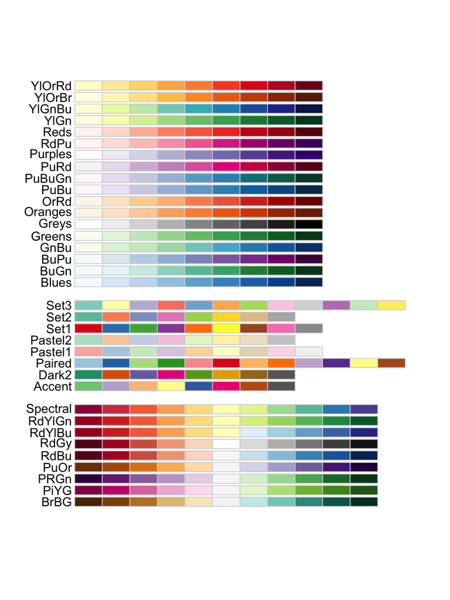

```r
# the lines above are special Quarto related syntax for formatting figures
# see the following link about figure options that can be set in quarto docs
# https://quarto.org/docs/reference/formats/html.html#figures

display.brewer.all()
```

### Color and fill

Color and fill are the chief aesthetic properties that are effected by palettes and in geoms that use both, they can be set indepedently. Color modify functions in ggplot start with `scale_color_` while fill modifying functions start with `scale_fill_`.

If we wish to use one of the RColorBrewer palettes to changes the color of points in a scatter plot, `scale_color_brewer` can be used:

```r
# For categorical data I like the "Dark2" color scheme
better_scatter +
  scale_color_brewer(palette = "Dark2")
```

Here’s another one of the RColorBrewer palettes.

```r
better_scatter +
  scale_color_brewer(palette = "Set1")
```

### Defining your own color palettes

If you want to define your own palette you can do it as so:

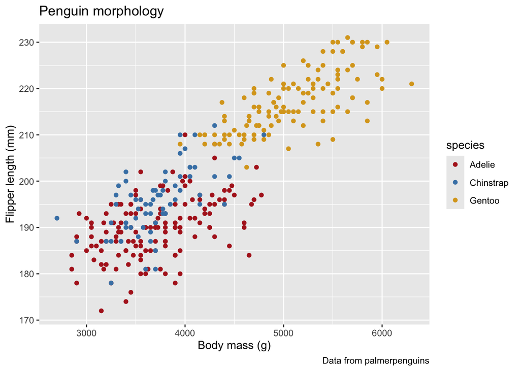

```r
# colors can be specified in various ways
# ggplot recognizes both hex codes, SVG color names (https://johndecember.com/html/spec/colorsvg.html)
# In this example we construct a custom palette using color names

custom_colors <- c("firebrick", "steelblue", "goldenrod")


better_scatter +
  scale_color_manual(values = custom_colors)
```

### scale_fill_ examples

`geom_density` and `geom_histogram` have both color and fill aesthetics:

```r
ggplot(tidy_data, aes(x = body_mass_g,
                     color = species,
                     fill = species)) +
  geom_density(alpha = 0.5) +
  scale_fill_brewer(palette = "Dark2") +
  scale_color_brewer(palette = "Dark2")
```

It can be useful to specify both fill and color palettes in a list, and assign that a variable name so you can refer to those settings easily:

```r
preferred_palette = "Dark2"

my_colors = list(
  scale_fill_brewer(palette = "Dark2"),
  scale_color_brewer(palette = "Dark2")
)


ggplot(tidy_data, aes(x = body_mass_g,
                     color = species,
                     fill = species)) +
  geom_density(alpha = 0.5) +
  my_colors
```

## Facets

Faceting is the process of subdividing our data based on one or more categorical variables when plotting.

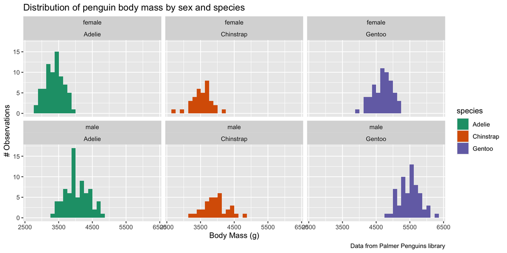

```r
# an example that involves filtering (via dplyr)
# and facetting to compare conditional distributions

tidy_data |>
  ggplot(aes(x = body_mass_g, fill = species)) +
  geom_histogram() +
  facet_wrap(vars(sex, species), ncol = 3) +
  labs(x = "Body Mass (g)", y = "# Observations",
       title = "Distribution of penguin body mass by sex and species",
       caption = "Data from Palmer Penguins library") +
  my_colors
```

## Annotations

### Highlighting via layers

A simple way to highlight data of interest is by layering geoms.

Here for example we highlight two points in a data set by stacking two `geom_point` layers:

```r
# highlight biggest and smallest penguins by body mass
tidy_data |>
  ggplot(aes(x = body_mass_g, y = flipper_length_mm)) +
  geom_point(
    data = filter(tidy_data,
                  body_mass_g >= max(body_mass_g) | body_mass_g <= min(body_mass_g)),
    color = "orange",
    size = 3) +
  geom_point()
```

### Annotating

ggplot has an `annotate` function for drawing text, line segments, curves, etc to explicitly call out features in plots.

From the `annotate` help: “This function adds geoms to a plot, but unlike a typical geom function, the properties of the geoms are not mapped from variables of a data frame, but are instead passed in as vectors”

Here’s an updated version of the figure above to which we’ve added text and arrows:

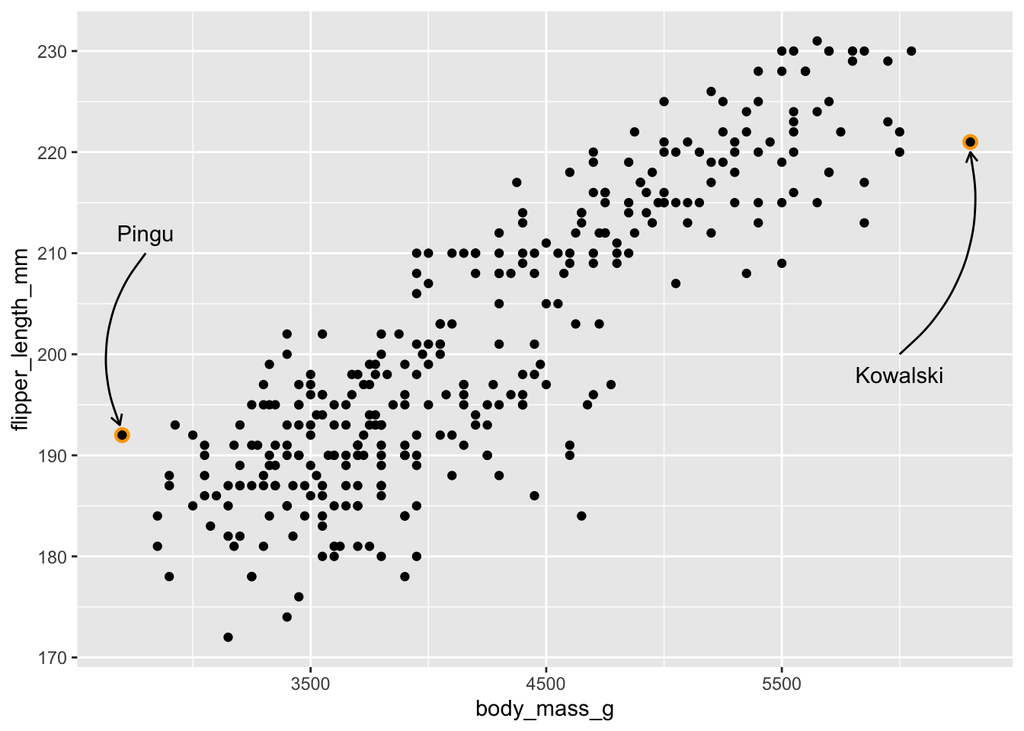

```r
tidy_data |>
  ggplot(aes(x = body_mass_g, y = flipper_length_mm)) +
  geom_point(
    data = filter(tidy_data,
                  body_mass_g >= max(body_mass_g) | body_mass_g <= min(body_mass_g)),
    color = "orange",
    size = 3) +
  geom_point() +
  annotate(geom = "curve",
           x = 6000, y = 200, xend = 6300, yend = 220,
           curvature = .3, arrow = arrow(length = unit(2, "mm"))) +
  annotate(geom = "text",
           x = 6000, y = 198,
           label = "Kowalski", hjust = "center") +
  annotate(geom = "curve",
           x = 2800, y = 210, xend = 2690, yend = 193,
          curvature = .3, arrow = arrow(length = unit(2, "mm"))) +
  annotate(geom = "text",
           x = 2800, y = 212,
           label = "Pingu", hjust = "center")
```

## Changing plot limits

If you want to change the limits of a plot, the recommended way to do so is to use the `coord_cartesian` function to specify x and y limits.

```r
# zoom in on a particular region of the plot
better_scatter +
  coord_cartesian(xlim = c(4000,5000), ylim=c(180,210))
```

```r
# zoom out to include origin
better_scatter +
  coord_cartesian(xlim = c(0,6500), ylim=c(0,240))
```

An alternate functions, `lims` can also be used to specify limits, but `lims` removes data rather than just changing the limits. This can be important if the plot includes a representation of a statistical function, such a linear model.

## Organizing subplots with patchwork

The [patchwork library](https://patchwork.data-imaginist.com/) is useful for combining multiple plots into a single figure.

Patchwork uses a simple syntax for specifying the layout of plots, as illustrated below. See the patchwork docs for more details and lots of examples:

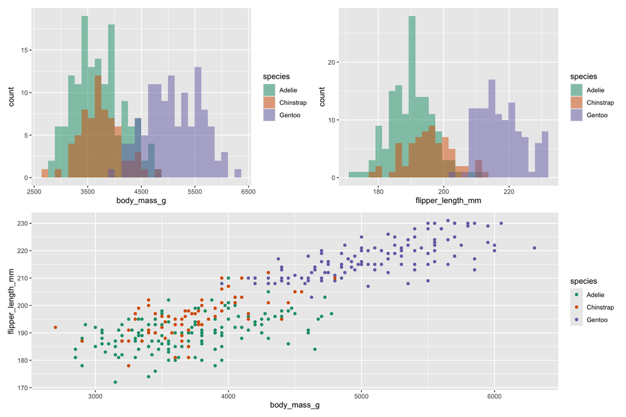

```r
plot1 <-
  ggplot(tidy_data,
         aes(x = body_mass_g,
             fill = species)) +
  geom_histogram(position = "identity",  # for non-stacked histograms
                 alpha = 0.5) +
  my_colors


plot2 <-
  ggplot(tidy_data,
         aes(x = flipper_length_mm,
             fill = species)) +
  geom_histogram(position = "identity",
                 alpha = 0.5) +
  my_colors


plot3 <-
  ggplot(tidy_data,
         aes(x = body_mass_g,
             y = flipper_length_mm,
             color = species)) +
  geom_point() +
  my_colors

# adding draws plots horizontally
# dividing specifies vertical stacking
fancy_plot <- (plot1 + plot2) / (plot3)

fancy_plot
```

## Exporting a plot

We can export using the `ggsave()` function. By default, `ggsave()` will save the last plot displayed:

```r
ggplot(tidy_data,
       aes(x = body_mass_g, y = flipper_length_mm)) +
  geom_point(alpha = 0.5) +
  my_colors
```

```r
ggsave("bodymass_vs_flipperlength.png", width = 7, height = 5, dpi = 300)
```

If you assign a plot to a variable, you can specify this as the `plot` argument to `ggsave`:

```r
ggsave("penguins_multi_plots.pdf", plot = fancy_plot,
       width = 12, height = 8)
```

Note that `ggsave` can infer the appropriate figure format from the filename.